# MG205: Econometrics Theory and Applications

Empirical Exercise 6: Discrimination

Jose Ignacio Gonzalez-Rojas

j.i.gonzalez-rojas@lse.ac.uk

London School of Economics and Political Science

## Today: From Panel Data to Experiments

### Bertrand & Mullainathan (2004)

#### Roadmap

1. Observational data cannot identify discrimination
2. Experiments can identify discrimination
3. White names receive 50% more callbacks
4. Improving your CV helps only if you are White

#### Last Week

- First differencing eliminates time-invariant unobservables
- Event studies with dynamic treatment effects
- Clustering standard errors for panel data

Today: what if the treatment itself is time-invariant?

# Observational Data Cannot Identify Discrimination

## Persistent Racial Gaps Demand an Explanation

### Labour Market Facts

#### The Facts

- African-Americans are twice as likely to be unemployed as Whites
- African-Americans earn 25% less when employed
- These gaps have persisted for decades

#### The Debate

Three competing views:

- Employers exhibit racial bias
- Market forces eliminate discrimination
- Data limitations prevent causal inference

The debate hinges on identification

## Unobservable Skills Prevent Causal Inference

### The OVB Problem

$$\begin{align*}
\log(\text{wage}_{it}) = \beta_{0} &+ \beta_{1}\mathbb{1}[\text{race}_{i} = \text{African American}] \\
&+ \beta_{2}\text{education}_{it} + \beta_{3}\text{experience}_{it} + e_{it}
\end{align*}$$

- Employers observe more than researchers
  - Unobservable skills are likely correlated with race
- Selection into employment biases wage estimates

## Panel Methods Cannot Identify Racial Discrimination

### The Treatment Is Time-Invariant

$$\Delta\log(\text{wage}_{it}) = \beta_{1}\underbrace{\Delta\mathbb{1}[\text{race}_{i}]}_{= \, 0} + \beta_{2}\Delta\text{education}_{it} + \beta_{3}\Delta\text{experience}_{it} + \Delta e_{it}$$

- Race does not change over time
  - First differencing eliminates the variable of interest
- FE and FD cannot identify time-invariant treatments

# Experiments Can Identify Discrimination

## Bertrand and Mullainathan Designed a Correspondence Study

### Bertrand & Mullainathan (2004)

#### Design

- Send fictitious resumes to real job postings
- Randomly assign racial signals through names
- Track callback rates by perceived race
- Four resumes per advertisement

#### Sample

- ~1,300 job advertisements
- ~5,000 resumes sent
- Boston Globe and Chicago Tribune
- July 2001 – May 2002

## Names Signal Perceived Race

### From Massachusetts Birth Certificates

#### White Names

- **Female:** Emily, Anne, Allison, Sarah
- **Male:** Brad, Greg, Geoffrey, Brendan

#### African-American Names

- **Female:** Lakisha, Tanisha, Keisha, Aisha
- **Male:** Jamal, Jermaine, Kareem, Darnell

Four resumes per ad: one high + one low quality per racial group

## Resume Quality Is Experimentally Varied

### High versus Low Quality Dimensions

| Dimension | High Quality | Low Quality |
| --- | --- | --- |
| Experience | More years | Less experience |
| Skills | Computer skills | Basic skills only |
| Certifications | External certifications | None |
| Extras | Volunteering, email address | Employment gaps |

## Randomisation Breaks Omitted Variable Bias

### The Identification Strategy

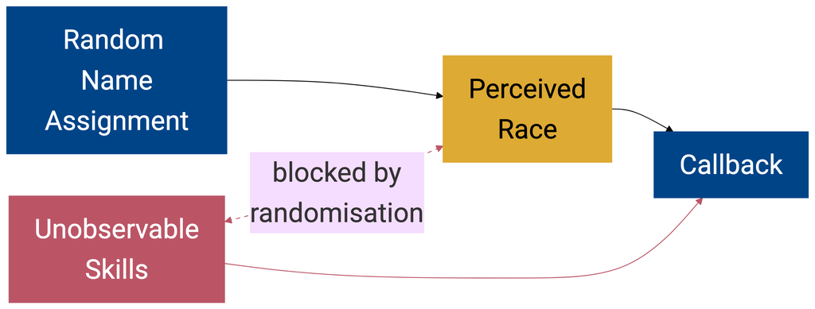

$$\mathbb{E}\left[e_{it} \mid \mathbb{1}[\text{race}_{i}]\right] = 0$$

Names are randomly assigned — all characteristics balanced. Simple regression gives a causal estimate. No controls needed.

## Balance Tests Confirm Randomisation Worked

### One rejection out of nine tests at 5% significance

| Variable | White mean | African-American mean | p-value |
| --- | --- | --- | --- |
| Years of experience | 7.86 | 7.83 | 0.85 |
| University education | 0.72 | 0.72 | 0.61 |
| Computer skills | 0.81 | 0.83 | **0.03** |
| Special skills | 0.33 | 0.33 | 0.83 |
| Volunteer work | 0.41 | 0.41 | 0.68 |
| Work in school | 0.56 | 0.56 | 0.84 |
| Employment holes | 0.45 | 0.45 | 0.77 |
| Military experience | 0.09 | 0.10 | 0.27 |
| Number of jobs | 3.66 | 3.66 | 0.86 |

# White Names Receive 50% More Callbacks

## White Applicants Receive Significantly More Callbacks

### Callback Rates by Race

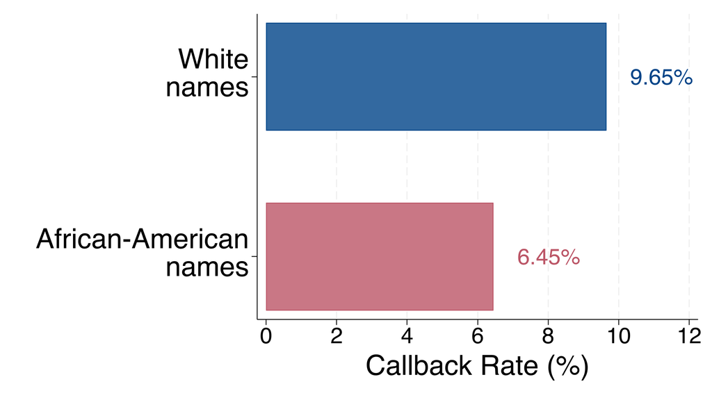

The difference is 3.20 percentage points — equivalent to approximately 8 years of additional experience.

## The Regression Confirms the Gap

### Estimated Model

$$\widehat{\mathbb{1}[\text{callback}]}_{i} = \underset{(0.0055)}{0.0965} - \underset{(0.0078)}{0.0320} \cdot \mathbb{1}[\text{race}_{i} = \text{African American}]$$

#### The Intercept

$\hat{\beta}_{0} = 0.0965$ is the White callback rate.

When the African-American indicator equals zero, the predicted callback rate equals the intercept.

#### The Slope

$\hat{\beta}_{0} + \hat{\beta}_{1} = 0.0645$ is the African-American callback rate.

The coefficient measures the racial gap: $-0.0320$ or $-3.20$ percentage points.

No controls needed — randomisation ensures $\text{Cov}(\mathbb{1}[\text{race}_{i}], e_{i}) = 0$.

## The Regression Coefficient Equals the Difference in Means

### A Mechanical Property of OLS

$$\hat{\beta}_{1} = \bar{y}_{\text{African American}} - \bar{y}_{\text{White}} = 0.0645 - 0.0965 = -0.0320$$

- Single binary regressor → OLS slope = difference in group means
- The t-test on $\hat{\beta}_{1}$ is identical to a two-sample t-test
- Mechanical property of OLS — proved in Topic 2

## Observational Studies Cannot Achieve This

### Experiments vs Panel Data

|  | Observational + Panel | Experiment |
| --- | --- | --- |
| Identification | OVB: skills confound race | $\mathbb{E}[e_{it} \mid \text{race}_{i}] = 0$ by design |
| Time-invariant treatment | FD eliminates the variable of interest | Randomisation sidesteps the problem |
| Controls | Never fully resolve confounding | Not needed |

Randomisation solves what panel data cannot

# Improving Your CV Helps Only If You Are White

## Discrimination Interacts with Resume Quality

### Callback Rates by Race and Quality

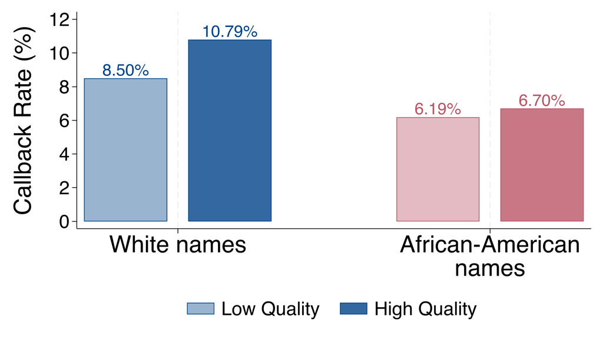

White low-quality applicants (8.50%) receive more callbacks than African-American high-quality applicants (6.70%).

## Discrimination Distorts Human Capital Incentives

### The Returns Trap

- White applicants: +27% return to quality (8.50% → 10.79%, p = 0.055)
- African-American applicants: +8% return to quality (6.19% → 6.70%, p = 0.604)
- If improving your CV does not improve your chances
  - Rational to underinvest in skills
- Discrimination turns a fairness problem into an efficiency problem

## The Gap Is Uniform Across the Labour Market

### Robustness

#### The racial gap is consistent across:

- All occupations (sales, administrative, clerical)
- All industries
- All employer sizes (small and large firms)
- Federal contractors do not discriminate less
- Equal Opportunity Employers do not discriminate less

“Lexicographic search” — employers may stop reading at African-American names

## The Study Has Four Limitations

### Scope and External Validity

1. **Callbacks ≠ hiring decisions**
   - First hurdle only — but fewer interviews mechanically reduce offers
2. **Names signal perceived race, not race per se**
   - No correlation between callbacks and mother’s education within race (Table 8)
3. **Newspaper advertisements are one channel**
   - Social networks and online platforms may differ
4. **External validity**
   - Boston and Chicago, 2001–2002

## Three Lessons from the Discrimination Experiment

1. Time-invariant treatments cannot be identified with panel methods
   - Race does not change over time — first differencing eliminates the variable of interest
2. Randomisation solves identification
   - Because names are randomly assigned: $\mathbb{E}[e_{i} \mid \text{race}_{i}] = 0$
   - No omitted variable bias, no controls needed
3. Returns to quality are asymmetric — discrimination distorts incentives
   - White applicants: +27% return to quality (p = 0.055)
   - African-American applicants: +8% return to quality (p = 0.604)

## After Reading Week: Differences-in-Differences

### Topic 8, Part 3

No class next week — reading week.

After reading week: finishing Topic 8 with **differences-in-differences**.

- Combining cross-sectional and time-series variation
- The parallel trends assumption
- Two-way fixed effects

# References

## References

Bertrand, M., & Mullainathan, S. (2004). Are Emily and Greg More Employable Than Lakisha and Jamal? A Field Experiment on Labor Market Discrimination. *American Economic Review*, *94*(4), 991–1013. https://doi.org/10.1257/0002828042002561